# Social Networks in R

These data frames have been previously prepared, based on the data from [50 influential people in Seattle tech to follow on Twitter](https://www.builtinseattle.com/2018/08/06/50-seattle-tech-twitter-accounts-to-follow). The file can be seen [here](https://docs.google.com/spreadsheets/d/e/2PACX-1vTpWvtfphnO9eRYwmEyxVAxxo1KEsdpK6sK6q5uhJn5x2QtB-eGiso8ibpF16NaHAers4wDIHkvBo64/pubhtml), and includes 3 sheets:

- Network as two columns representing edges.
- Network as adjacency matrix.
- Attributes of the Network nodes.

## I. Getting Ready:

- Libraries needed

```r
# Returns TRUE if installed, FALSE if not
# 1. Define the vector of packages you want to check
packages_to_check <- c("igraph","ggplot2","ggraph","rio")

# 2. Check all of them at once
sapply(packages_to_check, requireNamespace, quietly = TRUE)
```

```
##  igraph ggplot2  ggraph     rio
##    TRUE    TRUE    TRUE    TRUE
```

```r
###if needed

# install.packages(c('igraph','ggraph'))
```

- Set seed

```r
set.seed(123)
```

### II. Network Creation from dataframes

```r
rm(list = ls())
##
fileLink='https://github.com/DACSS-CSSmeths-summer/datafiles/raw/main/seattleTop.xlsx'

edges=rio::import(fileLink, which = 'edges')
adjacency=rio::import(fileLink, which = 'adjacency')
attributes=rio::import(fileLink,which ="attributes")
```

Use the previous dataframes to create the network:

- From the edges:

```r
library(igraph) # package needed
EliteNet=graph_from_data_frame(edges, directed = F)

summary(EliteNet)
```

```
## IGRAPH 26a3ff2 UN-- 46 393 --
## + attr: name (v/c)
```

- From adjacency matrix:

```r
#prepare matrix
row.names(adjacency)=adjacency[,1] #first column for index
adjacency=adjacency[,-1] # deleting the first column
adjacencyMatrix=as.matrix(adjacency)

# the making...
EliteNet=graph_from_adjacency_matrix(adjacencyMatrix,mode="undirected")


summary(EliteNet)
```

```
## IGRAPH 156bdc5 UN-- 46 393 --
## + attr: name (v/c)
```

See inside:

```r
V(EliteNet)
```

```
## + 46/46 vertices, named, from 156bdc5:
##  [1] rachelerman     mattmcilwain    DaveParkerSEA   toddbishop
##  [5] ashannstew      LeslieFeinzaig  akipman         matt_oppy
##  [9] gilbert         juliesandler    BradSmi         crashdev
## [13] ShaunaCausey    john_gabbert    moniguzman      mattmday
## [17] Rich_Barton     daryn           lovelletters    etzioni
## [21] MissDestructo   heatherredman   danshapiro      medinism
## [25] KieranSnyder    hadip           RajSinghSeattle funcOfJoe
## [29] kirbywinfield   stevesi         Ryanintheus     sonalpmane
## [33] SoGulley        2morrowknight   jinman          tarah
## [37] Jenerationy     lanctot         Kristen_Hammy   nhuntwalker
## + ... omitted several vertices
```

```r
E(EliteNet)
```

```
## + 393/393 edges from 156bdc5 (vertex names):
##  [1] rachelerman--mattmcilwain    rachelerman--DaveParkerSEA
##  [3] rachelerman--toddbishop      rachelerman--ashannstew
##  [5] rachelerman--LeslieFeinzaig  rachelerman--akipman
##  [7] rachelerman--matt_oppy       rachelerman--gilbert
##  [9] rachelerman--juliesandler    rachelerman--BradSmi
## [11] rachelerman--crashdev        rachelerman--ShaunaCausey
## [13] rachelerman--john_gabbert    rachelerman--moniguzman
## [15] rachelerman--mattmday        rachelerman--Rich_Barton
## [17] rachelerman--daryn           rachelerman--lovelletters
## [19] rachelerman--etzioni         rachelerman--MissDestructo
## + ... omitted several edges
```

### 2. Adding Attributes

Attributes are added using **vectors**:

```r
# edges
E(EliteNet)$weight=1
# EliteNet=set_edge_attr(EliteNet,"weight", value = 1)

#nodes
V(EliteNet)$male=attributes$male
V(EliteNet)$followers=attributes$followers
# EliteNet=set_vertex_attr(EliteNet, "followers", value=attributes$followers)
```

```r
##
# E(EliteNet)$weight
# edge_attr_names(EliteNet)
# V(EliteNet)$followers
# vertex_attr_names(EliteNet)
summary(EliteNet)
```

```
## IGRAPH 156bdc5 UNW- 46 393 --
## + attr: name (v/c), male (v/n), followers (v/n), weight (e/n)
```

You can use attributes to color nodes:

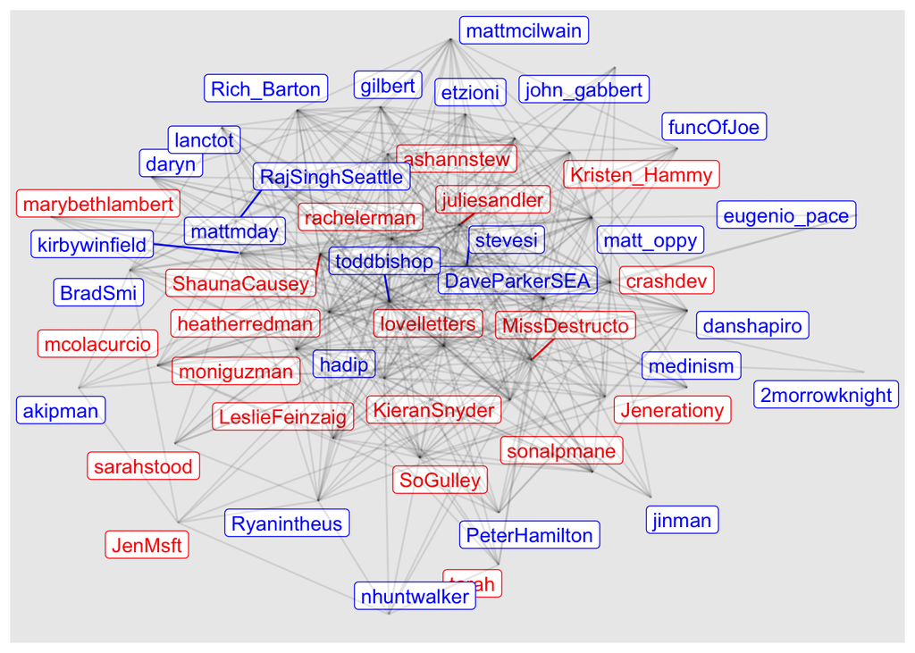

```r
library(ggraph)

base=ggraph(graph = EliteNet)
base + geom_node_label(aes(label = name,
                           color=as.factor(male)),
                       repel = TRUE,show.legend = F) +
       geom_edge_link(alpha=0.1) +
       scale_color_manual(values = c('red','blue'))
```

## III. Exploring the Network

Let’s some key measures that describe the whole network:

- Connectedness:

```r
is_connected(EliteNet)
```

```
## [1] TRUE
```

- Density:

```r
edge_density(EliteNet)
```

```
## [1] 0.3797101
```

- Diameter:

```r
diameter(EliteNet)
```

```
## [1] 3
```

- Assortativity:
1. Degree assortativity:

```r
assortativity_degree(EliteNet,directed=F)
```

```
## [1] -0.2541114
```

2. Categorical assortativity:

```r
assortativity_nominal(EliteNet,as.factor(V(EliteNet)$male),directed = F)
```

```
## [1] 0.04310211
```

3. Assortativity (numerical):

```r
assortativity(EliteNet,V(EliteNet)$followers,directed = T)
```

```
## [1] -0.04515662
```

## IV. Exploration of Network nodes

Let’s compute measures for each node, and save them into a data frame:

```r
eigen=eigen_centrality (EliteNet)$vector

close=closeness(EliteNet,normalized=T)

betw=betweenness(EliteNet,normalized=T)

DFCentrality=as.data.frame(cbind(eigen,close,betw),stringsAsFactors = F)
names(DFCentrality)=c('Eigenvector','Closeness','Betweenness')

DFCentrality$person=row.names(DFCentrality)
row.names(DFCentrality)=NULL

## see
head(DFCentrality)
```

```
##   Eigenvector Closeness Betweenness         person
## 1   0.8089981 0.7500000 0.038209947    rachelerman
## 2   0.4840837 0.6000000 0.004696161   mattmcilwain
## 3   0.9154314 0.8333333 0.098119429  DaveParkerSEA
## 4   1.0000000 0.9183673 0.111044213     toddbishop
## 5   0.5803118 0.6250000 0.004575579     ashannstew
## 6   0.5885513 0.6250000 0.003989266 LeslieFeinzaig
```

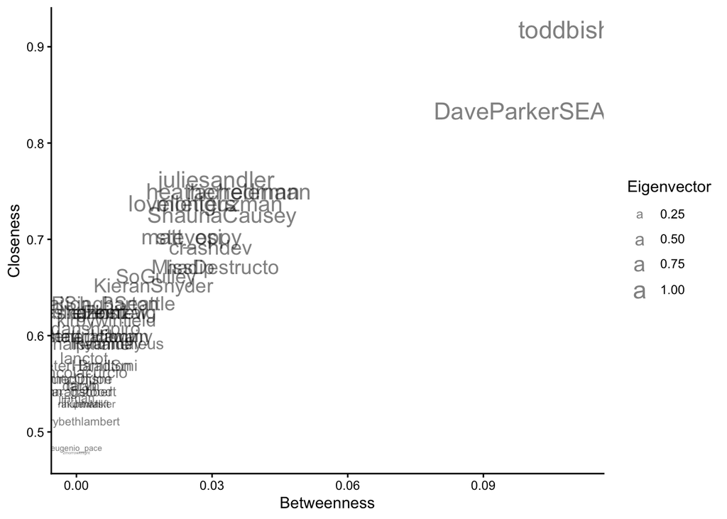

```r
library(ggplot2)
ggplot(DFCentrality, aes(x=Betweenness, y=Closeness)) +
    theme_classic() +
    geom_text(aes(label=person,size=Eigenvector),show.legend = T,alpha=0.5)
```

The previous results tells us that two people are salient:

```r
HubNodes=dplyr::top_n(DFCentrality,2,Eigenvector)$person
HubNodes
```

```
## [1] "DaveParkerSEA" "toddbishop"
```

Let’s highlight those guys:

```r
NodeCount=length(V(EliteNet))

V(EliteNet)$label=''

for (index in seq(1:NodeCount)){
    currentName=V(EliteNet)$name[index]
    if (currentName%in%HubNodes){
            V(EliteNet)$label[index]=currentName
    }
}
```

We show here only the hub’s names:

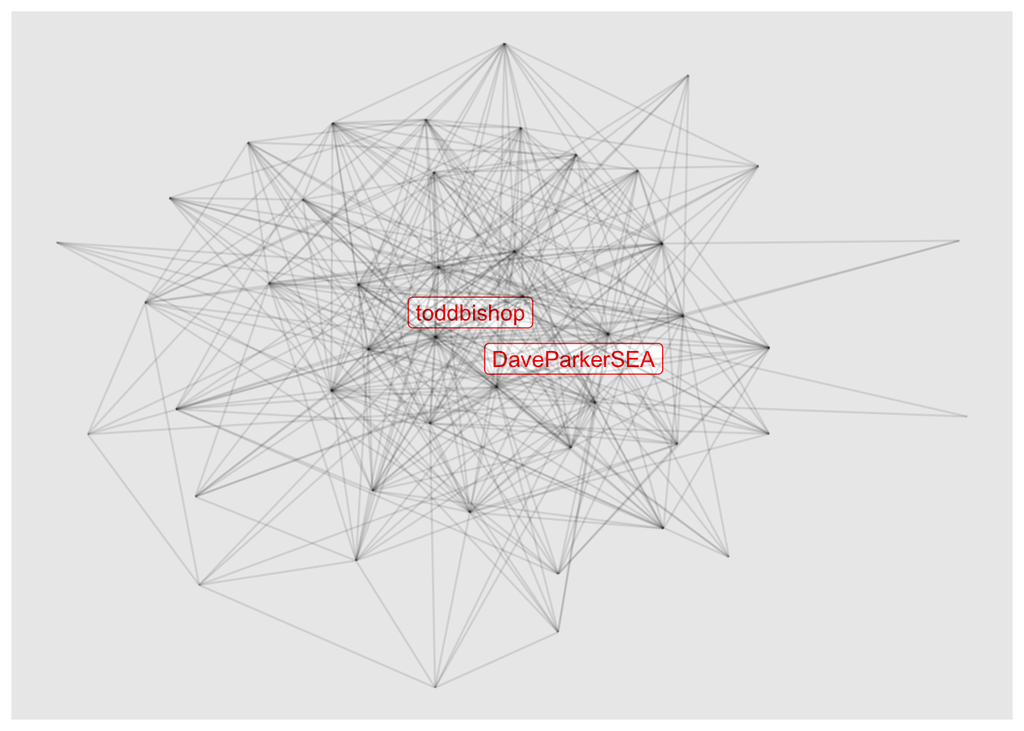

```r
library(ggraph)

base=ggraph(graph = EliteNet)
base  + geom_node_label(aes(label = label),
                        repel = TRUE,
                        show.legend = F,
                        color='red') +
         geom_edge_link(alpha=0.1)
```

## 5. Communities

### 5.1 **Potential Communities?**

1. A distribution of random network:

```r
# Generate an ensemble of 100 rewired random networks
set.seed(123)

random_transitivities <- replicate(100, {
  # rewire keeps the degree structure of EliteNet but randomizes edges
  RandomNet <- rewire(EliteNet, each_edge(prob = 1))
  transitivity(RandomNet)
})
```

2. The empirical transitivity - our own net

```r
# Calculate your empirical transitivity
empirical_transitivity <- transitivity(EliteNet)
```

3. Get Transitivity ratio

```r
# Get the ratio against the AVERAGE of the random networks
ratio <- empirical_transitivity / mean(random_transitivities)
ratio
```

```
## [1] 1.369203
```

As it is greater than 1, we continue:

### 5.2 **Two approaches**

1. Girvan-Newman:

The **girvan_newman** algorithm is based on creating partitions using the centrality of nodes to create partition too. We can create something similar to the last result like this:

```r
# Membership vector will be selected based
# on the highest modularity score
partition_girvanNewman_best <- cluster_edge_betweenness(EliteNet)
```

The best partition was

```r
table(membership(partition_girvanNewman_best))
```

```
##
##  1  2  3  4  5  6  7  8  9
## 38  1  1  1  1  1  1  1  1
```

The modularity:

```r
max(partition_girvanNewman_best$modularity)
```

```
## [1] 0.004059592
```

2. Louvain:

```r
partition_louvain_optimal <- cluster_louvain(EliteNet)
```

The optimal partition is:

```r
table(membership(partition_louvain_optimal))
```

```
##
##  1  2  3  4  5
##  8 11 11  6 10
```

The modularity:

```r
max(partition_louvain_optimal$modularity)
```

```
## [1] 0.1095669
```

### 5.3 **Plotting communities**

First, adding the community label to the nodes:

```r
V(EliteNet)$louvain=as.factor(membership(partition_louvain_optimal))

V(EliteNet)$girvanNewman=as.factor(membership(partition_girvanNewman_best))
```

Now plot the one with the best modularity:

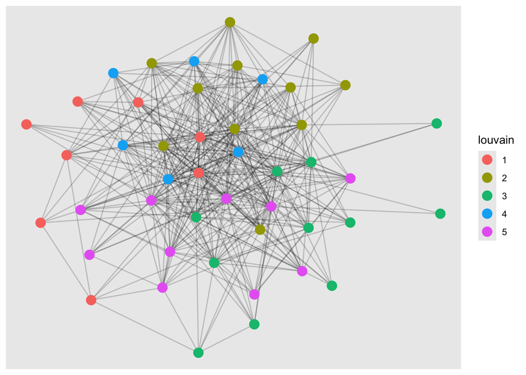

```r
base=ggraph(graph =EliteNet) +
          geom_edge_link(alpha=0.2)

base + geom_node_point(aes(color=louvain),
                       show.legend = T, size=4)
```

An alternative:

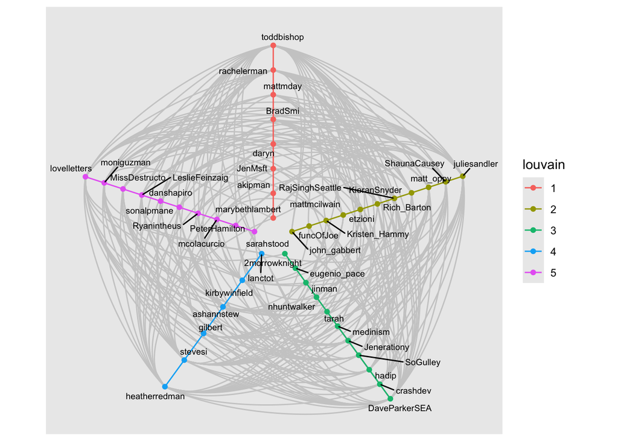

```r
V(EliteNet)$degree = degree(EliteNet) # first compute node degree and assign

ggraph(EliteNet, layout = 'hive',
       axis = louvain,
       sort.by = degree
       ) +
  geom_edge_hive(color='grey80') +
  geom_axis_hive(aes(colour = louvain),
                 label = F) +
  geom_node_point(aes(colour = louvain)) +
  geom_node_text(aes(label = name),
                 repel = TRUE,
                 max.overlaps = 50, # avoid overlap
                 size = 2.5) +
  coord_fixed()
```

Time to export:

```r
# you need numeric here:
V(EliteNet)$louvain=as.numeric(V(EliteNet)$louvain)
V(EliteNet)$girvanNewman=as.numeric(V(EliteNet)$girvanNewman)
# so this works
write_graph(EliteNet, "EliteNet_R.graphml", "graphml")
```